# ggplot Cheatsheet

[figure not shown]

# 1 Introduction

The purpose of this document is to provide some helpful information on using ggplot(). This document was created by Neil Yetz on 10/08/2020. In this document I talk about the essential concepts regarding the ggplot() function. I then provide standardized code for creating wonderful ggplot() graphs.

## 1.1 The Basics of ggplot()

ggplot requires three essential components to run:

- 1.) *Data*: Provided as your first argument (or using “data =”)
- 2.) An *aesthetic*: Abbreviated *aes()*, This is where you can “map” your x and/or y variables as well as many other variables.
- 3.) a *geom_* layer: A geom_ layer takes on many forms. For example if you want to create a boxplot, the geom_ layer is “geom_boxplot()”. Want to create a histogram? “geom_histogram()”. Correlation? “geom_point()”. You can add layers by using a “+” sign.

Below is the most basic ggplot() graph.

```
ggplot(data, aes(x = variable)) +
  geom_layer()
```

# 2 Popular geom_layers

In this section, I write the most basic syntax for some of the more popular geom_layers that you will likely be utilizing throughout your career.

## 2.1 geom_histogram()

geom_histogram is a univariate layer (It only requires an x axis to be mapped in your aes() ).

For example:

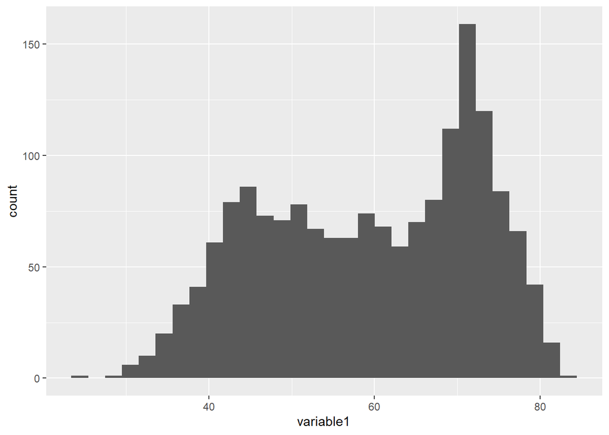

```r
ggplot(yourdata, aes(x = variable1)) +
  geom_histogram()
```

### 2.1.1 Special features with geom_histogram()

#### 2.1.1.1 Setting binwidth

You can change the binwidth of a histogram by using the “binwidth =” argument in your geom_histogram layer. For example:

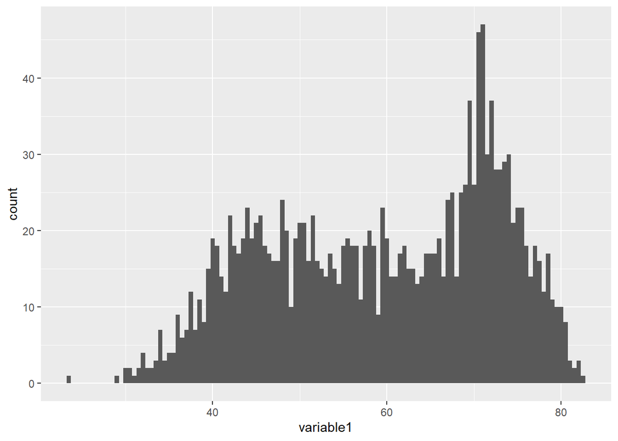

```r
ggplot(yourdata, aes(x = variable1)) +
  geom_histogram(binwidth = 0.5)
```

## 2.2 geom_density()

geom_density is a univariate layer (It only requires an x axis to be mapped in your aes() ).It is very similar to geom_histogram, but the y-axis is a proportion, rather than a count

For example:

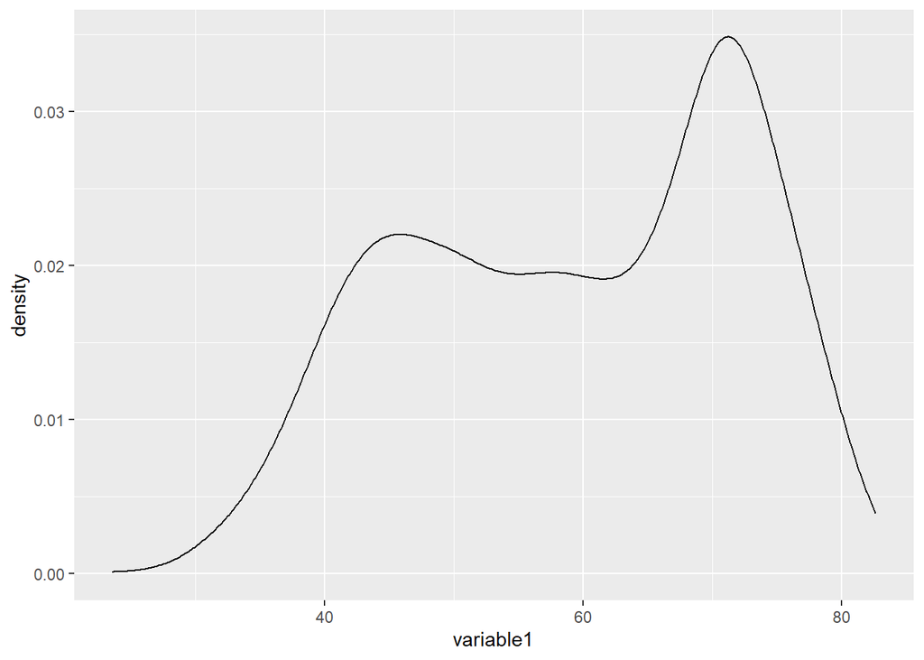

```r
ggplot(yourdata, aes(x = variable1)) +
  geom_density()
```

## 2.3 geom_boxplot()

geom_boxplot is a univariate layer (It only requires an x or y axis to be mapped in your aes() )

For example:

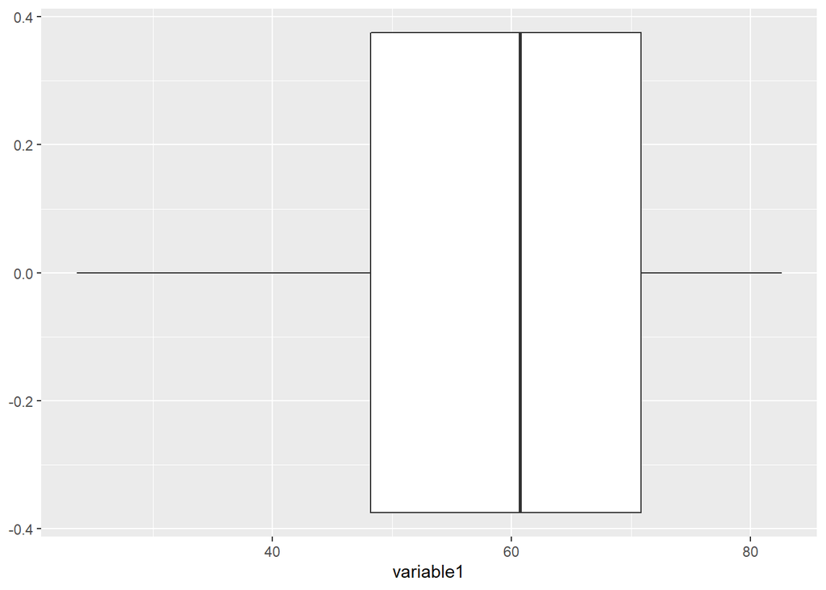

```r
ggplot(yourdata, aes(x = variable1)) +
  geom_boxplot()
```

geom_boxplot() also allows you to map a single y-axis if you’d like your boxplot to be vertical. For example

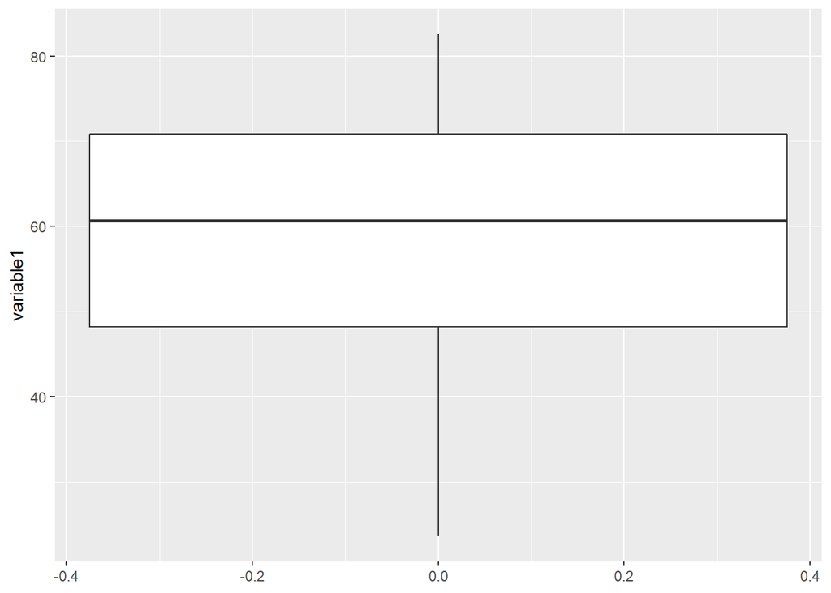

```r
ggplot(yourdata, aes(y = variable1)) +
  geom_boxplot()
```

## 2.4 geom_bar()

geom_bar creates a bar plot and is a univariate layer (It only requires an x or y axis to be mapped in your aes() ). Additionally, your x variable need to be categorical. For example:

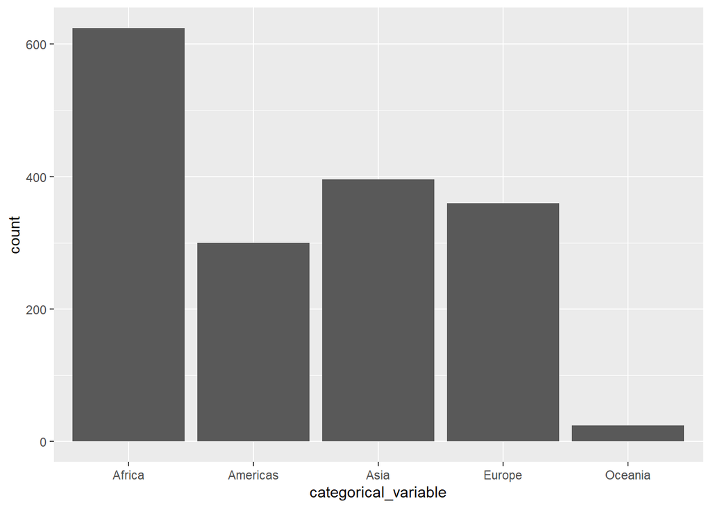

```r
ggplot(yourdata, aes(x = categorical_variable)) +
  geom_bar()
```

geom_bar() also allows you to map a single y-axis if you’d like your barplot to be flipped. For example

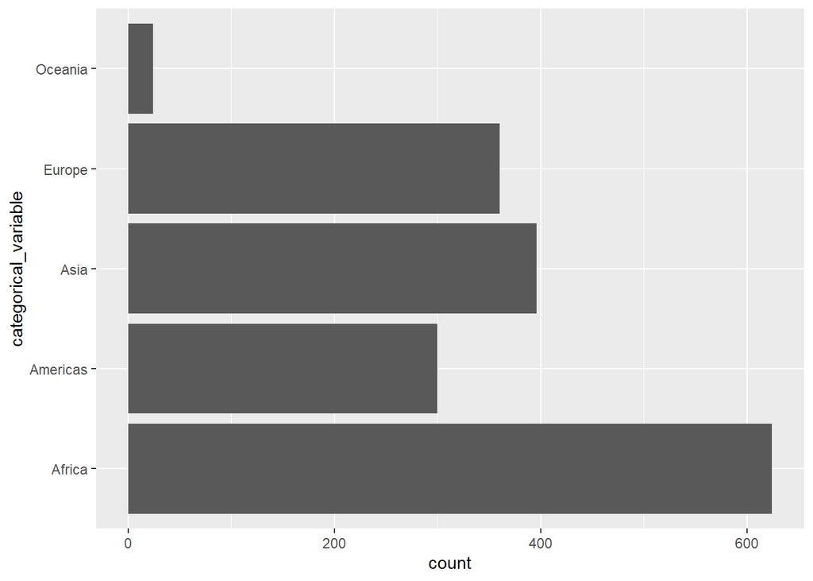

```r
ggplot(yourdata, aes(y = categorical_variable)) +
  geom_bar()
```

## 2.5 geom_point()

geom_point creates a scatterplot and is a bivariate layer (It requires an x AND a y axis in the aes() ). Both variable need to be continuous. For example:

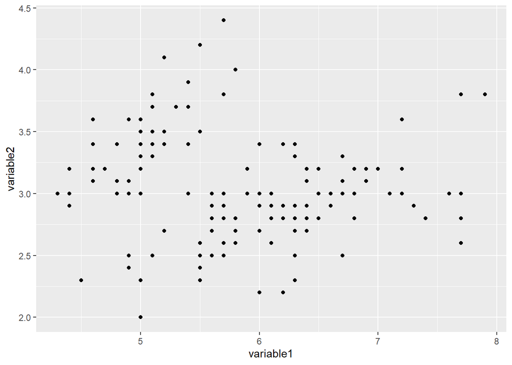

```r
ggplot(yourData, aes(x = variable1, y = variable2)) +
  geom_point()
```

## 2.6 geom_smooth()

geom_smooth creates a regression line and is a bivariate layer (It requires an x AND a y axis in the aes() ). Both variable need to be continuous. For example:

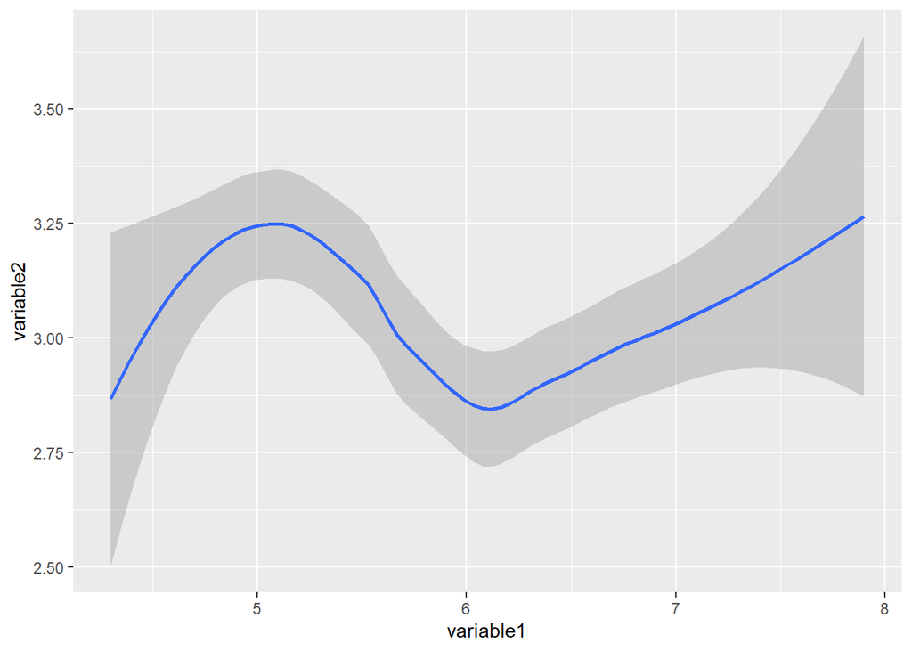

```r
ggplot(yourData, aes(x = variable1, y = variable2)) +
  geom_smooth()
```

### 2.6.1 Special features with geom_smooth()

#### 2.6.1.1 Adding best fit linear line

You can set the best fir linear line using " method = “lm” "

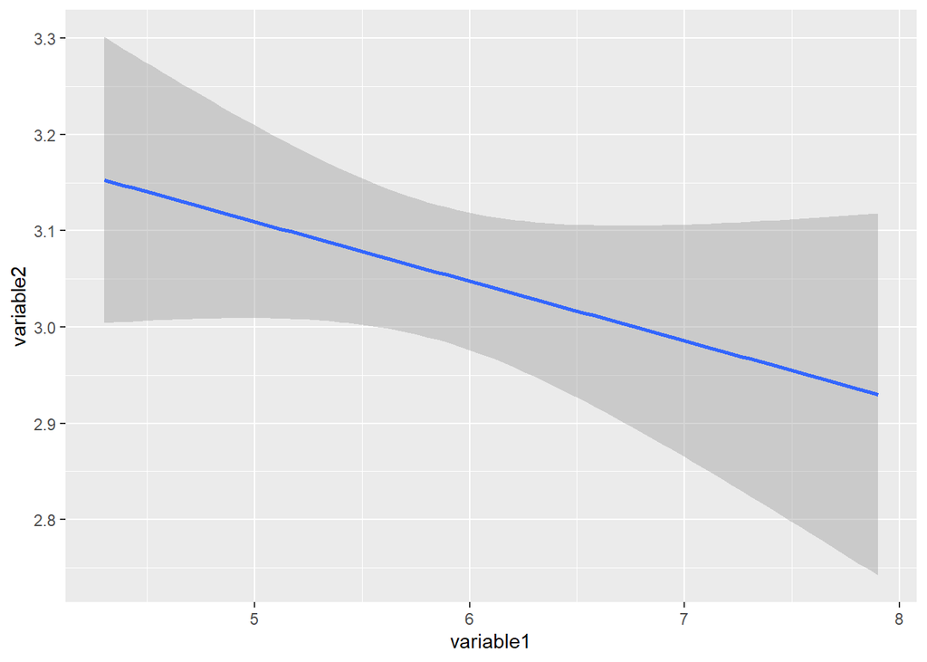

```r
ggplot(yourData, aes(x = variable1, y = variable2)) +
  geom_smooth(method = "lm")
```

## 2.7 geom point() + geom_smooth()

Often times, it is appropriate to combine our geom_point() and geom_smooth() layer. This overlays a regression line on top of your scatterplot. For example:

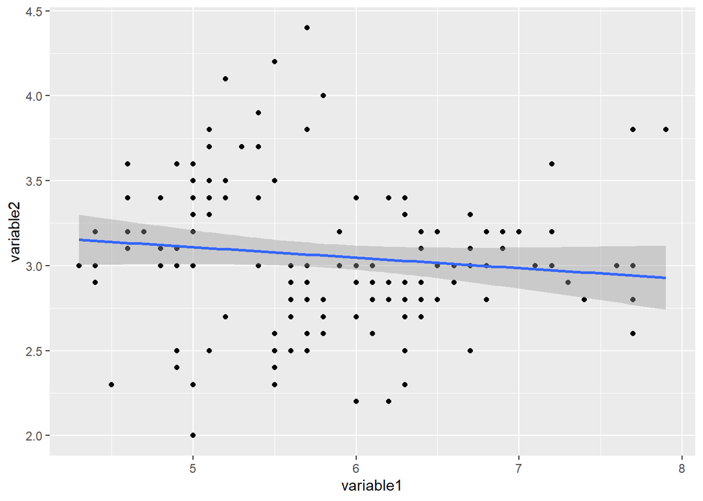

```r
ggplot(yourData, aes(x = variable1, y = variable2)) +
  geom_point() +
  geom_smooth(method = "lm")
```

# 3 Other popular layers

In this section, I outline other useful layers beond that of popular geom_layers.

## 3.1 facet_wrap()

The facet_wrap() layer allows you to separate graphs out by a categorical variable. To indicate the variable we would like to facet by, we use a “~” within the facet_wrap() layer.

In general, it looks as so:

```
facet_wrap(~categorical_variable)
```

For example, when combined with other geom_boxplot:

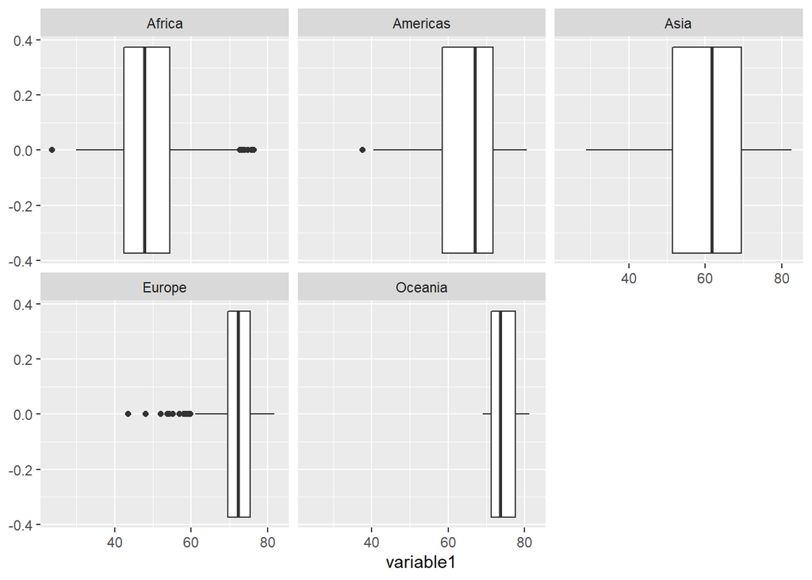

```r
ggplot(yourdata, aes(x = variable1)) +
  geom_boxplot() +
  facet_wrap(~categorical_variable)
```

or with a geom_scatterplot:

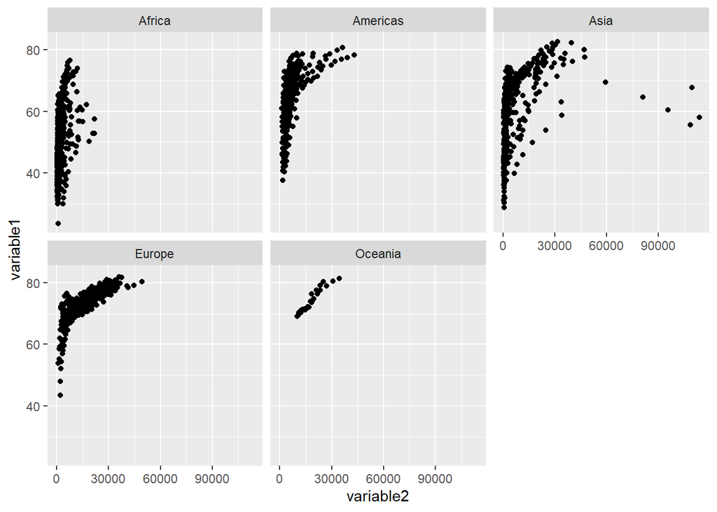

```r
ggplot(yourdata, aes(x = variable2, y = variable1)) +
  geom_point() +
  facet_wrap(~categorical_variable)
```

## 3.2 labs()

The labs() layer allows you to add labels to your plot. You can add:

- A title (title = )
- A subtitle (subtitle = )
- An x-axis label (x = )
- A y-axis label (y = )

For example:

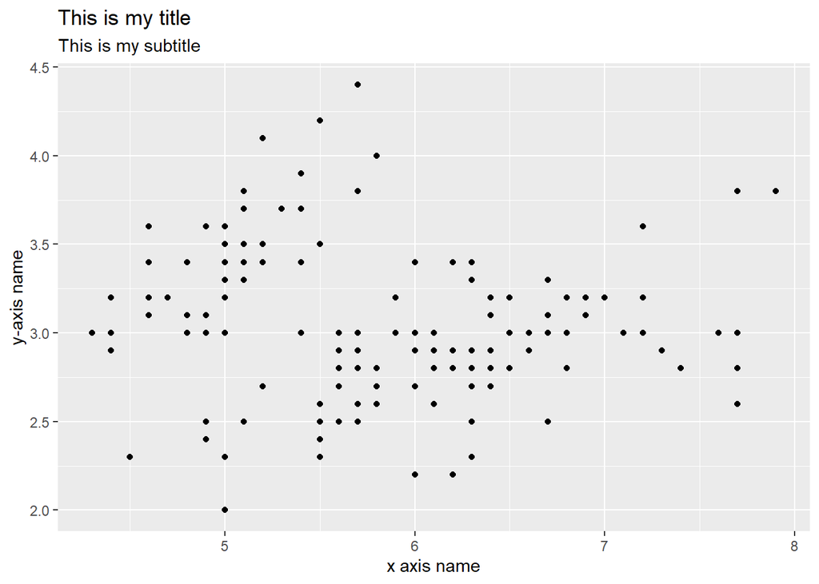

```r
ggplot(yourData, aes(x = variable1, y = variable2)) +
  geom_point() +
  labs(title = "This is my title",
       subtitle = "This is my subtitle",
       x = "x axis name",
       y = "y-axis name")
```

# 4 Popular aesthetics

Aesthetics have many more features beyond mapping your x and y variables to your geom_ layer. You can also color by variable levels. You can fill by a categorical variable or a continuous variable.

## 4.1 fill =

Use fill = within your aes() in order to color by a variable level.

For example, filling by a categorical variable:

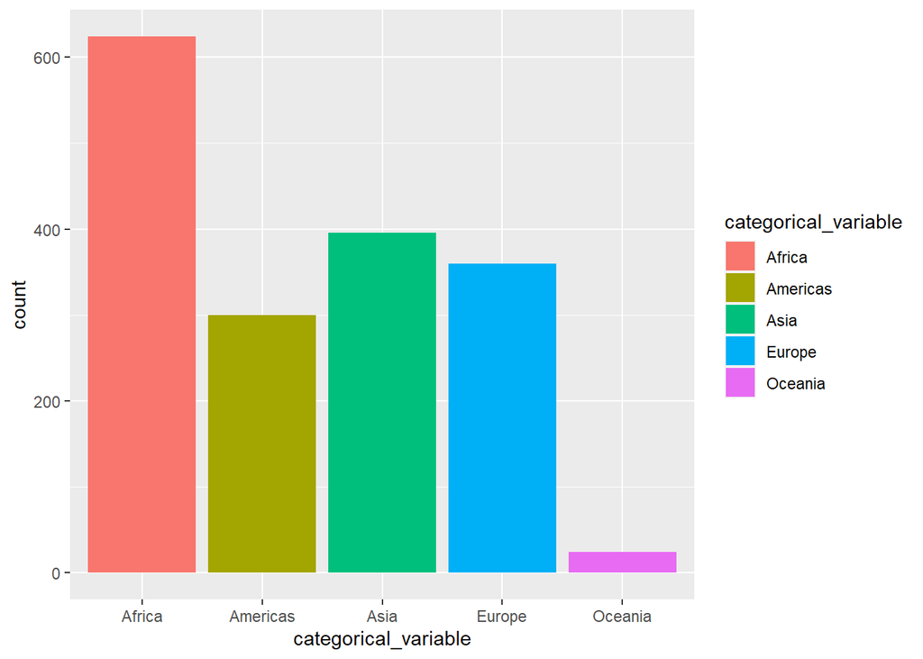

```r
ggplot(yourdata, aes(x = categorical_variable, fill = categorical_variable)) +
  geom_bar()
```

## 4.2 color =

use “color =” within your aes() function to color your scatterplots by variable

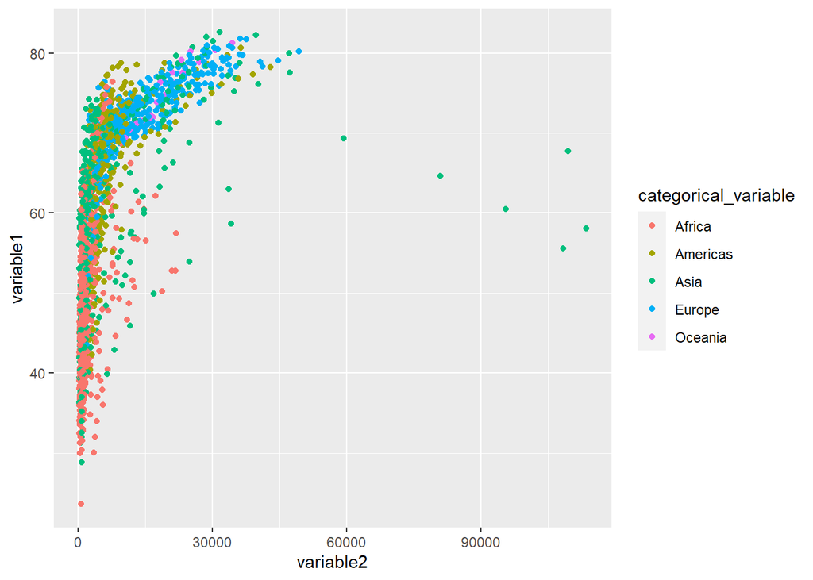

```r
ggplot(yourdata, aes(x = variable2, y = variable1, color = categorical_variable)) +
  geom_point()
```

## 4.3 shape =

use “shape =” within your aes() function to have adifferent shapes mapped to your scatterplots by variable

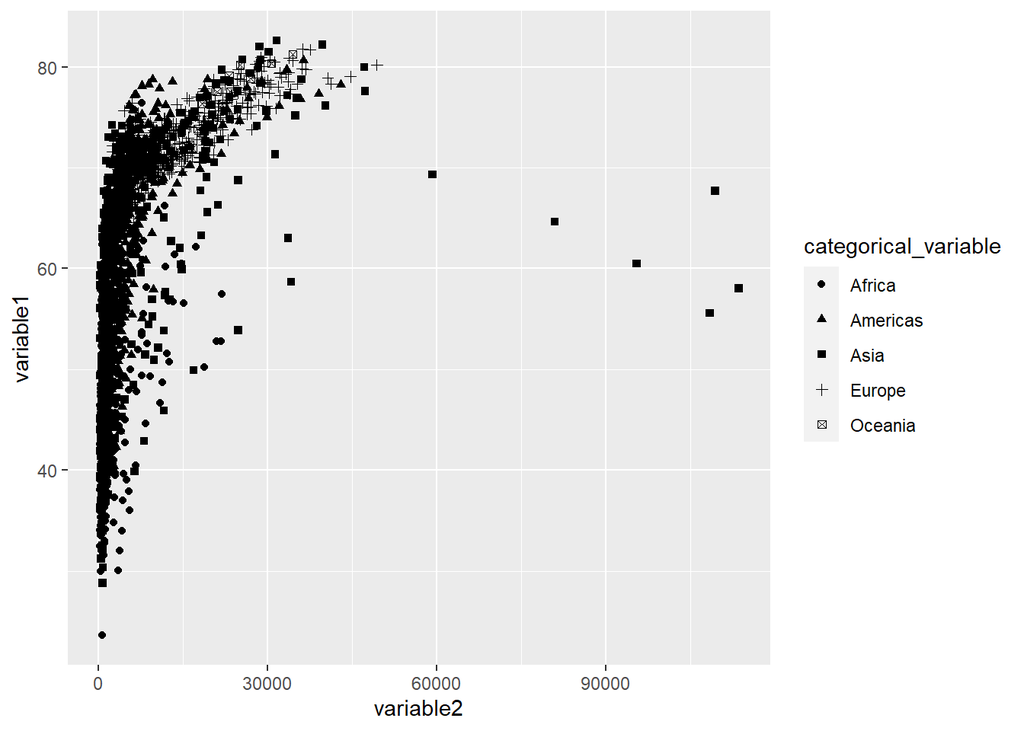

```r
ggplot(yourdata, aes(x = variable2, y = variable1, shape = categorical_variable)) +
  geom_point()
```

# 5 Put it together!

You can Have multiple layers and/or aesthetics into one graph!

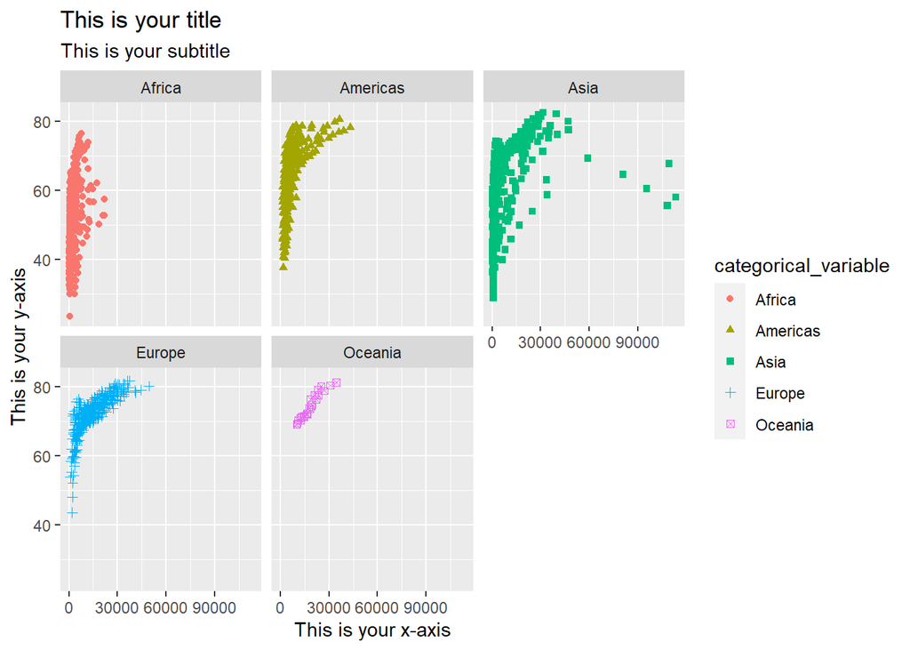

```r
ggplot(yourdata, aes(x = variable2, y = variable1, color = categorical_variable, shape = categorical_variable)) +
  geom_point() +
  facet_wrap(~categorical_variable) +
  labs(title = "This is your title",
       subtitle = "This is your subtitle",
       x = "This is your x-axis",
       y = "This is your y-axis")
```